# Week 5 In Class Lab

Moving from Scripts to Functions

Tong Jin

10/01/2019

Today’s lab session introduced a function buildup method:

Moving from Scripts to Functions

The lab uses the 1973 New York Air Quality Measurements (`airquality`) dataset as an example.

This document is heavily-commented and step-by-step featured.

### Function

The $function$ is to plot median lines among data points.

It contains two layers.

The second layer is to shift the $batchSize$ of data points to the right, one point each, and repeat $batchSize$ times. This is realized by adding an `NA` data point at the beginning of the index vector.

##### To sum up, the $function$ calls the following steps:

1. Create a variable called $batchSize$. It determines how large each slice is. We can create plot lines with different slice size through changing the value of this variable. In this case, we preset the value to 11.

The syntax is:

```r
batchSize <- 11
```

2. Create a variable called airWind and assign the $Wind$ vector in the $airquality$ dataset to it, so that we don’t need to type $airquality\$Wind$ every time we need this vector. THe $airWind$ variable has 153 data. (`dim(airWind)[1]`)

The syntax is:

```r
airWind <- airquality$Wind
```

3. Assign the length of $airWind$ to a new variable called $leng$.

The syntax is:

```r
leng <- length(airWind)
```

4. Create an $index$ vector with the length equal to the length of target data. The content of the index will be a repeated vector with 153 original values, each being repeated by $batchSize$ times.

The syntax is `index <- rep(1:leng, each = batchSize)`

– For example:

if $batchSize = 5$, we will get:

[1] 1 1 1 1 1 2 2 2 2 2 3 3 3 3 3 4 4 4 4 4 5 5 5 5 5 6 6 6 6 6

…

[760] 152 153 153 153 153 153

Since the index is used for indexing the data points in our target dataset, there is no need to list the index vector all the way to the end. We only need a portion of the index which is equal to $leng$ (the length of the target dataset). We can use `[1: leng]` to select the values we want.

The updated syntax is:

```r
index <- rep(1:leng, each = batchSize)[1: leng]
```

5. Create a list vector called $medResults$ and set the number of lists contained to $batchSize$. This list set is used to store the calculation results performed in the second layer of the $function$.

The syntax is:

```r
medResults <- vector("list", length = batchSize)
```

6. We now need to perform the first layer by running a $tapply$ function. The $tapply$ function computes a measure (mean, median, min, max, etc..) or a function for each factor variable in a vector. In this case, we will calculate the median of the $airWind$ in a way as specified by the $index$. The syntax is: `tapply(airWind, INDEX = index, FUN = "median")`.

Each time we perform the `tapply`, we need to store the result to the preset list $medResults$. We use double brackets to index the list set.

– For example:

To store the first `tapply` result to the first list in $medResults$, we can use: `medResults[[1]] <- tapply(airWind, INDEX = index, FUN = "median")`.

7. As we calculate the medians, we want to shift the slices to the right to include a new data point and dump one each time so that we can plot the trend of medians as the data spread. To save the efforts of calculating medians repeatedly, we use a `for loop` to automate the process. Inside the loop, we can add an `NA` value at the beginning to the $index$ each time to simulate the shift. (`tapply` does not process `NA` values in `INDEX`.)

Like this: ([n] represents repeat times, $batchSize$ = 5)

[1] 1 1 1 1 1 2 2 2 2 2 …

[2] NA 1 1 1 1 1 2 2 2 2 2 …

[3] NA NA 1 1 1 1 1 2 2 2 2 2 …

[4] NA NA NA 1 1 1 1 1 2 2 2 2 2 …

[5] NA NA NA NA 1 1 1 1 1 2 2 2 2 2 …

The `tapply` kicks in after `NA` values. Thus, at the 5th loop, the `tapply` will calculate the median of [5:9] instead of [1:5].

As `NA` values beging added at the beginning, the length of $index$ will increase each time by 1. So we can add `[1:leng]` at the end to control the length.

The for loop syntax is:

```r
for (i in 1:batchSize) {
    medResults[[i]] <- tapply(airWind, INDEX = index, FUN = "median")
    index <- c(NA, index)[1:leng]
}
```

Inside the loop, we create a local variable called $i$. $i$ is used for counting loops. The syntax `(i in 1: batchSize)` means we want to perform the loop with $batchSize$ times. $i$ is also used for indexing the list layers in the $medResults$. Each time, the loop will run the `tapply` function and generate a vector of median results. Then, the loop assigns the result to the $i$th list in $medResults$. In this way, $medResults$ will contain all results from the loop, layer by layer, in different indexed lists.

8. As we fill up the $medResults$, we now have $batchSize$ lists of the median results, the length of each list is equal to $\frac{leng}{batchSize}$. Since $medResults$ is a list set, we need to export the values inside to a vector in order to plot a median line. Therefore, we need to create another for loop to do repetition.

First, create a matrix called $smoothMatrix$ that is filled up with `NA` values. To match the dimension of $medResults$, we set the number of row to be equal to $\frac{leng}{batchSize}$. We use `ceiling` function to round the value to the next upper integer. The number of columns should be equal to $batchSize$. Then, we use a for loop to export each list inside the $medResults$ to the $smoothMatrix$.

The syntax is:

```r
smoothMatrix <- matrix(NA, nrow = ceiling(leng/batchSize), ncol = batchSize)
for (i in 1:batchSize) {
    vals <- medResults[[i]]
    smoothMatrix[1:length(vals), i] <- vals
}
# The local variable, vals, inside the loop is just a bridge and has no
# global meanings.
```

9. Now we have a matrix, $smoothMatrix$, that contains median results by column.

```r
smoothMatrix
```

```
##       [,1] [,2] [,3] [,4]  [,5] [,6]  [,7] [,8]  [,9] [,10] [,11]
##  [1,] 11.5 11.5 11.5 10.9 10.90 10.9 10.90 11.5 11.50  10.9  10.9
##  [2,] 11.5 11.5 11.5 12.0 12.00 12.0 12.00 12.0 12.00  12.0  12.0
##  [3,]  9.7 12.0  9.7  9.2  9.20  9.7  9.20  9.2  9.70   9.7   9.7
##  [4,]  9.7  9.7 10.9 11.5 11.50 11.5 11.50 11.5 10.90  10.3  10.3
##  [5,] 10.3  9.2  8.0  8.0  8.00  8.0  8.00  8.0  8.00   8.0   9.2
##  [6,]  9.2  9.2  9.2  9.2  8.00  7.4  7.40  8.6  8.60   8.6   8.6
##  [7,]  8.6  8.6  8.6  8.6 10.30 10.3 10.30 10.3  9.70   8.6   8.6
##  [8,]  8.6  8.6  8.6  8.6  8.60  8.6  8.60  8.0  7.40   7.4   7.4
##  [9,]  7.4  7.4  7.4  7.4  7.40  8.0  8.00  8.6  9.70  10.3  10.3
## [10,] 10.3 10.3 10.3 10.9 10.90 10.9 10.30 10.3 10.30   9.7   9.7
## [11,]  9.7  9.7  8.0  6.9  6.30  6.3  5.70  6.3  6.30   6.3   6.3
## [12,]  6.9  7.4  9.7 10.3 10.30 10.9 10.90 10.9 10.90  10.9  10.9
## [13,] 10.3 10.9 10.3 10.3 10.30 10.3 10.30 10.3 10.30  10.3  10.3
## [14,] 10.9 10.3 10.9 11.5 12.35 11.5 12.35 11.5  9.75  11.5    NA
```

We want to transfer the matrix to a vector with result values in correct order. To realize this, we use `t` function to transpose the matrix and use `as.vector` to switch the data type to vector. For convenience, we assign a name $smoothAirWind$ to it.

The syntax is:

```r
smoothAirWind <- as.vector(t(smoothMatrix))
```

10. Finally, we can plot a median line with the vector.

The syntax is:

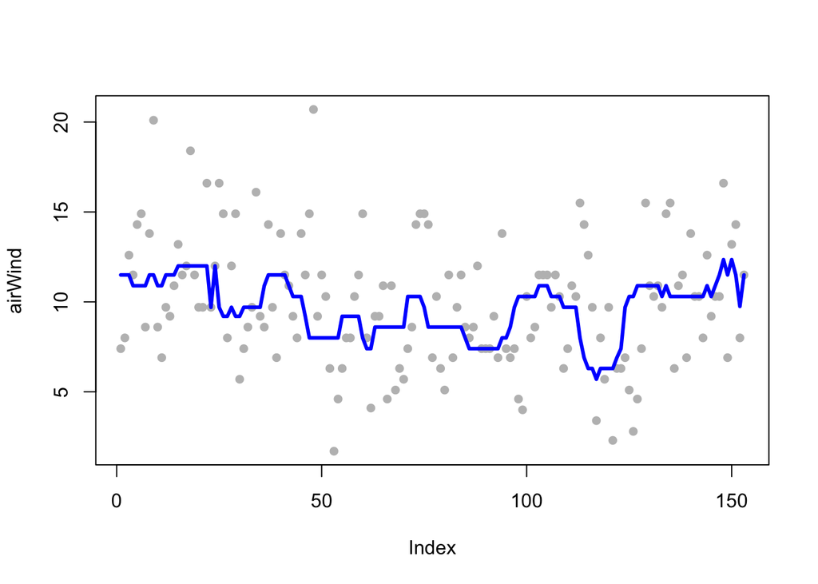

```r
plot (airWind,       pch = 16, col = 8)
# pch - point character style

# col - color

# lwd - line width
lines(smoothAirWind, lwd = 3,  col = "blue")
```

11. As all scripts above are functional, we can pack them into a function: `myRunMeds`.

It has two variables:

$x$ - the target data (as a vector)

$batchSize$ - the slice size, set dafault to 5

The syntax is:

```r
myRunMeds <- function(x, batchSize = 5) {
    leng <- length(x)
    index <- rep(1:leng, each = batchSize)[1:leng]
    medResults <- vector("list", length = batchSize)

    for (i in 1:batchSize) {
        medResults[[i]] <- tapply(x, INDEX = index, FUN = "median")
        index <- c(NA, index)[1:leng]
    }

    smoothMatrix <- matrix(NA, nrow = ceiling(leng/batchSize), ncol = batchSize)

    for (i in 1:batchSize) {
        vals <- medResults[[i]]
        smoothMatrix[1:length(vals), i] <- vals
    }

    return(as.vector(t(smoothMatrix)))
}
```

12. We can now test the function.

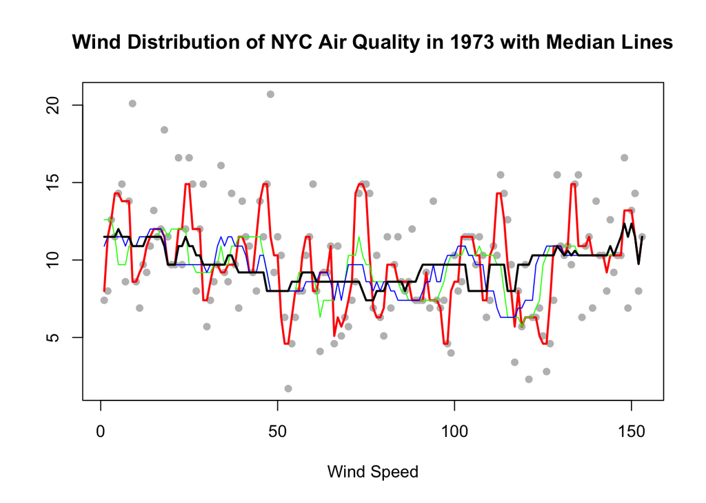

```r
plot(airquality$Wind, pch = 16, col = 8, ann = FALSE)
title(main = "Wind Distribution of NYC Air Quality in 1973 with Median Lines",
    xlab = "Wind Speed", cex = 0.8)
# pch - point character

# col - color

# ann - default annotation (title, x-label, y-label), omit if set to FALSE

# xlab - x-label

# cex - character expansion ratio

lines(myRunMeds(airquality$Wind, batchSize = 3), col = "red", lwd = 2)
lines(myRunMeds(airquality$Wind, batchSize = 9), col = "green")
lines(myRunMeds(airquality$Wind, batchSize = 15), col = "blue")
lines(myRunMeds(airquality$Wind, batchSize = 25), col = "black", lwd = 2)
```

As $batchSize$ increases, the median line will be smoother. This is because more values are involved in the calculation of median, causing much less fluctuation.